# Reproducible Research Peer Assessment I

Brendan Murphy

Friday, October 17, 2014

### About

This **Project I** for the John Hopkins **Reproducible Research** course in Coursera.

## Assignment

The purpose of this project was to practice:

- Loading and preprocessing data
- Finding the mean of the total number of Steps taken in a day
- Finding the average daily activity pattern
- Imputing missing values
- Discerning differences in activity patterns between weekdays and weekends

## Data

The data for this assignment can be downloaded from the course website site:

Dataset: [Activity monitoring data](https://d396qusza40orc.cloudfront.net/repdata%2Fdata%2Factivity.zip)

The variables included in this dataset are:

- steps: Number of steps taking in a 5-minute interval (missing values are coded as `NA`)
- date: The date on which the measurement was taken in YYYY-MM-DD format
- interval: Identifier for the 5-minute interval in which measurement was taken

The dataset is stored in a comma-separated-value (CSV) file and there are a total of 17,568 observations in this dataset.

## Loading and preprocessing the data

Load data into data frame `stepData`.

```r
stepData <- read.csv("activity.csv")
```

## What is mean total number of steps taken per day?

Total steps, make a Histogram, and calculate mean and median of total number of steps taken each day.

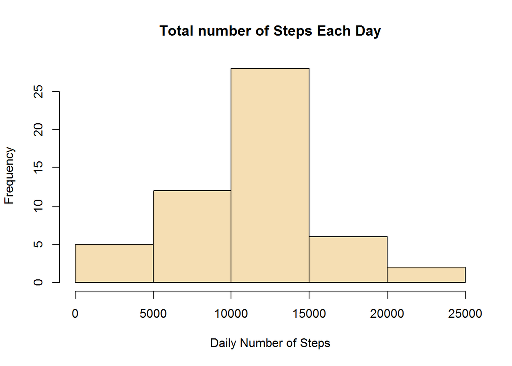

```r
stepsPerDay <- aggregate(steps ~ date, stepData, sum)
hist(stepsPerDay$steps, main = paste("Total number of Steps Each Day"), col="wheat", xlab="Daily Number of Steps")
```

```r
stepsMean <- mean(stepsPerDay$steps)
stepsMedian <- median(stepsPerDay$steps)
```

- The mean is 1.0766 × 10<sup>4</sup>.
- The median is 10765.

## What is the average daily activity pattern?

- Make a time series plot of 5 min interval(x-axis) and average number of steps taken, averaged across all days
- Determine 5 min interval with maximum number of average steps.

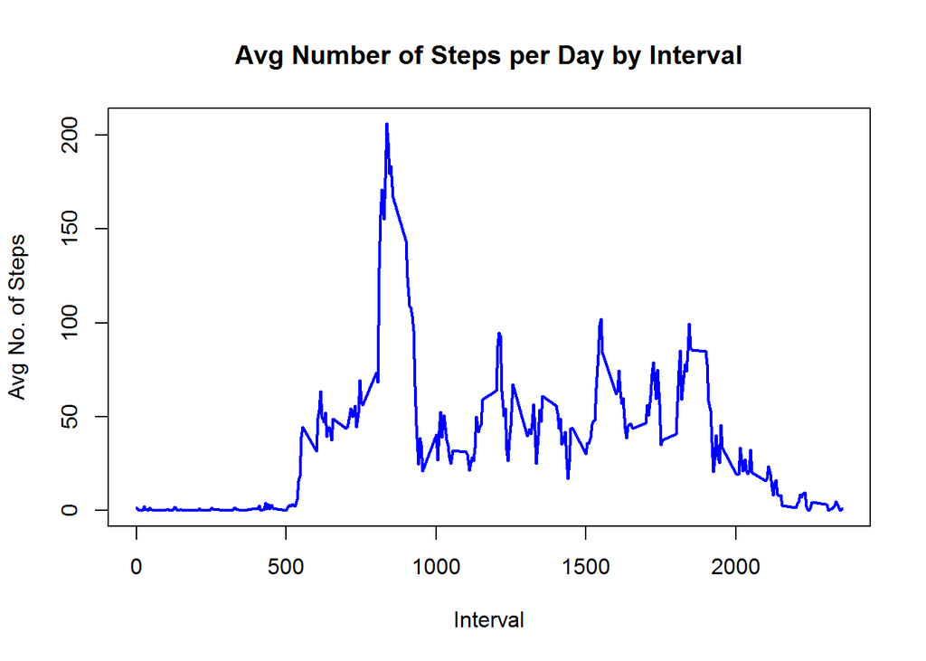

```r
stepsInterval <- aggregate(steps ~ interval, stepData, mean)

plot(stepsInterval$interval,stepsInterval$steps, type="l", col = "blue", lwd = 2,
     xlab="Interval", ylab="Avg No. of Steps",main="Avg Number of Steps per Day by Interval")
```

```r
maxInterval <- stepsInterval[which.max(stepsInterval$steps),1]
```

The 5 minute interval that contains maximum number of steps is 835

## Impute missing values.

There are a number of days/intervals where there are missing values (coded as NA). The presence of missing days may introduce bias into some calculations or summaries of the data.

- Calculate and report the total number of missing values in the dataset (i.e. the total number of rows with NAs)
- Missing values were imputed by inserting the average for each interval and Zeroes were imputed for 10-01-2012 because it was the first day.
- we then create a new dataset that is equal to the original dataset but with the missing data filled in.
- We make a histogram of the total number of steps taken each day and Calculate and report the mean and median total number of steps taken per day.

```r
missingVals <- sum(!complete.cases(stepData))
```

The total number of missing values in the dataset is 2304

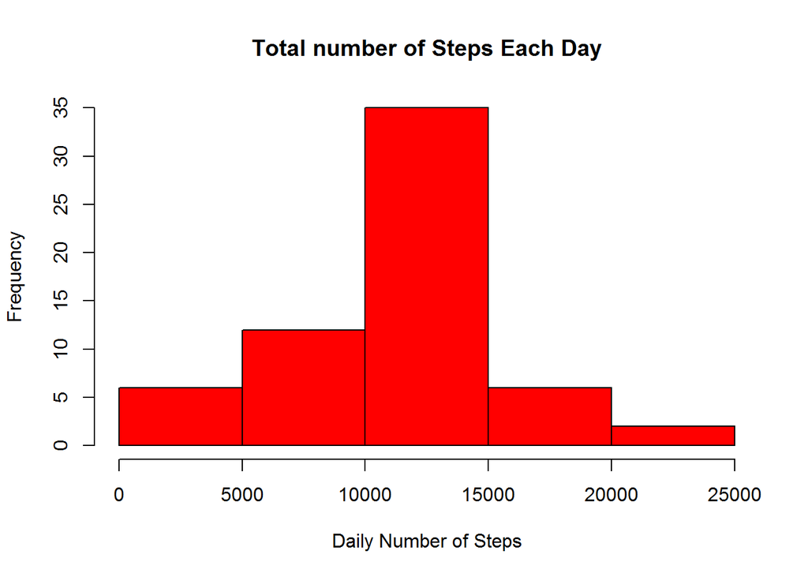

```r
newStepsData <- transform(stepData, steps = ifelse(is.na(stepData$steps), stepsInterval$steps[match(stepData$interval, stepsInterval$interval)], stepData$steps))
newStepsData[as.character(newStepsData$date) == "2012-10-01", 1] <- 0

newStepsPerDay <- aggregate(steps ~ date, newStepsData, sum)
hist(newStepsPerDay$steps, main = paste("Total number of Steps Each Day"), col="red", xlab="Daily Number of Steps")
```

```r
newStepsMean <- mean(newStepsPerDay$steps)
newStepsMedian <- median(newStepsPerDay$steps)

meanDiff <- newStepsMean - stepsMean
medianDiff <- newStepsMedian - stepsMedian
totalStepsDiff <- sum(newStepsPerDay$steps) - sum(stepsPerDay$steps)
```

- The new mean is 1.059 × 10<sup>4</sup>.
- The new median is 1.0766 × 10<sup>4</sup>.
- The difference between old and new mean is -176.4949.
- The difference between old and new median is 1.1887.

## Are there differences in activity patterns between weekdays and weekends?

Here we create a new factor variable in the dataset with two levels - “weekday” and “weekend” indicating whether a given date is a weekday or weekend day.

We then have a plot containing a time series plot (i.e. type = “l”) of the 5-minute interval (x-axis) and the average number of steps taken, averaged across all weekday days or weekend days (y-axis).

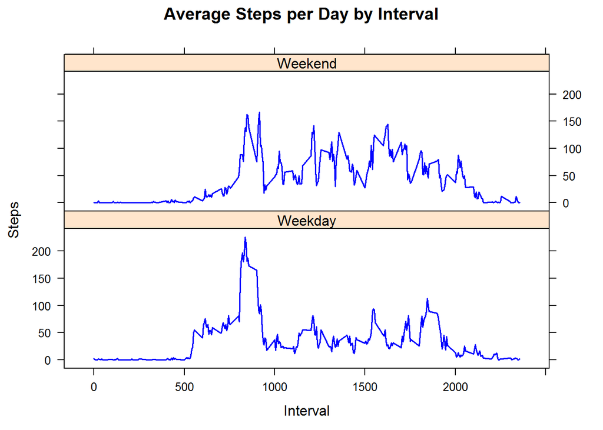

```r
weekDay <- c("Monday", "Tuesday", "Wednesday", "Thursday",
              "Friday")
newStepsData$dType = as.factor(ifelse(is.element(weekdays(as.Date(newStepsData$date)),weekDay), "Weekday", "Weekend"))

dtypeData <- aggregate(steps ~ interval + dType, newStepsData, mean)

library(lattice)

xyplot(dtypeData$steps ~ dtypeData$interval|dtypeData$dType, main="Average Steps per Day by Interval",
       xlab="Interval", ylab="Steps",layout=c(1,2), type="l",col = "blue", lwd = 1.5)
```